# Online Book RFM Data

## 1. Perform descriptive statistics on all variables to help understand the data

```python
import pandas as pd
import numpy as np
import datetime as dt
import seaborn as sns
import matplotlib.pyplot as plt
import warnings
import re
import squarify
warnings.filterwarnings("ignore")
df = pd.read_excel('Final Assignment - Week 9.xlsx')
```

```python
df.head()
```

|  | id | logtarg | r | f | m | tof | Ffiction1 | Fclassics3 | Fcartoons5 | Flegends6 | ... | MGamesRiddles38 | Msports39 | Mhobby40 | Mnature41 | Mencyclopaedia44 | Mvideos50 | Mnonbooks99 | Unnamed: 66 | Unnamed: 67 | Dear Greg, |
| --- | --- | --- | --- | --- | --- | --- | --- | --- | --- | --- | --- | --- | --- | --- | --- | --- | --- | --- | --- | --- | --- |
| 0 | 914 | NaN | 194 | 7 | 318.894775 | 1703 | 1 | 0 | 1 | 0 | ... | 0.0 | 0.0 | 0.000000 | 0.000000 | 0.0 | 0.000000 | 0.0 | NaN | NaN | NaN |
| 1 | 957 | NaN | 3 | 14 | 368.052246 | 2364 | 1 | 0 | 2 | 0 | ... | 0.0 | 0.0 | 61.176025 | 17.150269 | 10.0 | 0.000000 | 0.0 | NaN | NaN | I wanted to find something that the students c... |
| 2 | 1406 | NaN | 1489 | 15 | 423.298340 | 2371 | 0 | 0 | 0 | 0 | ... | 0.0 | 0.0 | 0.000000 | 0.000000 | 0.0 | 0.000000 | 0.0 | NaN | NaN | NaN |
| 3 | 1414 | NaN | 155 | 4 | 71.217041 | 1290 | 0 | 0 | 0 | 0 | ... | 0.0 | 0.0 | 0.000000 | 0.000000 | 0.0 | 0.000000 | 0.0 | NaN | NaN | I have data from American Science and Surplus,... |
| 4 | 1546 | NaN | 194 | 6 | 442.638184 | 2188 | 0 | 0 | 1 | 0 | ... | 0.0 | 0.0 | 17.895203 | 0.000000 | 0.0 | 61.799988 | 0.0 | NaN | NaN | NaN |

5 rows × 69 columns

```python
def missing_perc(df):
    """
    Function to calculate missing data % by column
    given a data frame

    """
    missing_df = pd.DataFrame()
    missing_df['Col Name'] = list(df.columns)
    missing_df['Missing %'] = [round(i/df.shape[0] * 100,2) for i in df.isnull().sum()]
    missing_df.sort_values(by=['Missing %'], ascending=False,inplace=True)
    missing_df['Missing %'] = missing_df['Missing %'].astype('str') + '%'
    pd.set_option('display.max_rows', None)
    return missing_df
# Calculate missing data % per column
missing_perc(df)
```

|  | Col Name | Missing % |
| --- | --- | --- |
| 66 | Unnamed: 66 | 100.0% |
| 67 | Unnamed: 67 | 100.0% |
| 68 | Dear Greg, | 99.99% |
| 1 | logtarg | 75.35% |
| 65 | Mnonbooks99 | 0.0% |
| 49 | Meconomy21 | 0.0% |
| 36 | Mfiction1 | 0.0% |
| 37 | Mclassics3 | 0.0% |
| 38 | Mcartoons5 | 0.0% |
| 39 | Mlegends6 | 0.0% |
| 40 | Mphilosophy7 | 0.0% |
| 41 | Mreligion8 | 0.0% |
| 42 | Mpsychology9 | 0.0% |
| 43 | Mlinguistics10 | 0.0% |
| 44 | Mart12 | 0.0% |
| 45 | Mmusic14 | 0.0% |
| 46 | Mfacsimile17 | 0.0% |
| 47 | Mhistory19 | 0.0% |
| 48 | Mconthist20 | 0.0% |
| 50 | Mpolitics22 | 0.0% |
| 64 | Mvideos50 | 0.0% |
| 51 | Mscience23 | 0.0% |
| 35 | Fnonbooks99 | 0.0% |
| 53 | Mrailroads27 | 0.0% |
| 54 | Mmaps30 | 0.0% |
| 55 | Mtravelguides31 | 0.0% |
| 56 | Mhealth35 | 0.0% |
| 57 | Mcooking36 | 0.0% |
| 58 | Mlearning37 | 0.0% |
| 59 | MGamesRiddles38 | 0.0% |
| 60 | Msports39 | 0.0% |
| 61 | Mhobby40 | 0.0% |
| 62 | Mnature41 | 0.0% |
| 63 | Mencyclopaedia44 | 0.0% |
| 52 | Mcompsci26 | 0.0% |
| 0 | id | 0.0% |
| 33 | Fencyclopaedia44 | 0.0% |
| 16 | Ffacsimile17 | 0.0% |
| 2 | r | 0.0% |
| 3 | f | 0.0% |
| 4 | m | 0.0% |
| 5 | tof | 0.0% |
| 6 | Ffiction1 | 0.0% |
| 7 | Fclassics3 | 0.0% |
| 8 | Fcartoons5 | 0.0% |
| 9 | Flegends6 | 0.0% |
| 10 | Fphilosophy7 | 0.0% |
| 11 | Freligion8 | 0.0% |
| 12 | Fpsychology9 | 0.0% |
| 13 | Flinguistics10 | 0.0% |
| 14 | Fart12 | 0.0% |
| 15 | Fmusic14 | 0.0% |
| 17 | Fhistory19 | 0.0% |
| 32 | Fnature41 | 0.0% |
| 18 | Fconthist20 | 0.0% |
| 19 | Feconomy21 | 0.0% |
| 20 | Fpolitics22 | 0.0% |
| 21 | Fscience23 | 0.0% |
| 22 | Fcompsci26 | 0.0% |
| 23 | Frailroads27 | 0.0% |
| 24 | Fmaps30 | 0.0% |
| 25 | Ftravelguides31 | 0.0% |
| 26 | Fhealth35 | 0.0% |
| 27 | Fcooking36 | 0.0% |
| 28 | Flearning37 | 0.0% |
| 29 | FGamesRiddles38 | 0.0% |
| 30 | Fsports39 | 0.0% |
| 31 | Fhobby40 | 0.0% |
| 34 | Fvideos50 | 0.0% |

```python
df = df.drop(['Unnamed: 66','Unnamed: 67','Dear Greg,','logtarg'],axis=1,inplace=False)
```

```python
df.describe()
```

|  | id | r | f | m | tof | Ffiction1 | Fclassics3 | Fcartoons5 | Flegends6 | Fphilosophy7 | ... | Mhealth35 | Mcooking36 | Mlearning37 | MGamesRiddles38 | Msports39 | Mhobby40 | Mnature41 | Mencyclopaedia44 | Mvideos50 | Mnonbooks99 |
| --- | --- | --- | --- | --- | --- | --- | --- | --- | --- | --- | --- | --- | --- | --- | --- | --- | --- | --- | --- | --- | --- |
| count | 3.371300e+04 | 33713.000000 | 33713.000000 | 33713.000000 | 33713.000000 | 33713.000000 | 33713.000000 | 33713.000000 | 33713.000000 | 33713.000000 | ... | 33713.000000 | 33713.000000 | 33713.000000 | 33713.000000 | 33713.000000 | 33713.000000 | 33713.000000 | 33713.000000 | 33713.000000 | 33713.000000 |
| mean | 8.234209e+06 | 508.427254 | 5.820603 | 251.924325 | 1296.088186 | 0.590900 | 0.228102 | 0.356480 | 0.104767 | 0.290659 | ... | 29.095301 | 4.223431 | 21.147507 | 0.305226 | 0.020681 | 6.785558 | 3.728635 | 8.402428 | 6.020431 | 1.800973 |
| std | 4.426015e+06 | 542.440039 | 7.008049 | 3929.929826 | 818.976321 | 1.762201 | 0.865510 | 1.105653 | 0.527764 | 1.088606 | ... | 2087.221131 | 19.975164 | 2898.452008 | 1.991675 | 0.501499 | 21.197488 | 15.007592 | 46.021881 | 19.643978 | 21.383867 |
| min | 9.140000e+02 | 0.000000 | 0.000000 | 0.000000 | 0.000000 | 0.000000 | 0.000000 | 0.000000 | 0.000000 | 0.000000 | ... | 0.000000 | 0.000000 | 0.000000 | 0.000000 | 0.000000 | 0.000000 | 0.000000 | 0.000000 | 0.000000 | 0.000000 |
| 25% | 4.391616e+06 | 117.000000 | 1.000000 | 39.899994 | 536.000000 | 0.000000 | 0.000000 | 0.000000 | 0.000000 | 0.000000 | ... | 0.000000 | 0.000000 | 0.000000 | 0.000000 | 0.000000 | 0.000000 | 0.000000 | 0.000000 | 0.000000 | 0.000000 |
| 50% | 7.967691e+06 | 293.000000 | 3.000000 | 102.629944 | 1311.000000 | 0.000000 | 0.000000 | 0.000000 | 0.000000 | 0.000000 | ... | 0.000000 | 0.000000 | 0.000000 | 0.000000 | 0.000000 | 0.000000 | 0.000000 | 0.000000 | 0.000000 | 0.000000 |
| 75% | 1.199823e+07 | 712.000000 | 7.000000 | 247.297485 | 2132.000000 | 1.000000 | 0.000000 | 0.000000 | 0.000000 | 0.000000 | ... | 18.899994 | 0.000000 | 2.500000 | 0.000000 | 0.000000 | 5.112919 | 0.000000 | 0.000000 | 0.000000 | 0.000000 |
| max | 1.625264e+07 | 2460.000000 | 118.000000 | 532892.000000 | 2462.000000 | 109.000000 | 29.000000 | 49.000000 | 22.000000 | 35.000000 | ... | 383154.500000 | 820.563477 | 532182.000000 | 78.724670 | 21.448685 | 771.610840 | 735.354980 | 1999.150391 | 794.137695 | 2412.960938 |

8 rows × 65 columns

```
array([[<AxesSubplot:title={'center':'r'}>,
        <AxesSubplot:title={'center':'f'}>],
       [<AxesSubplot:title={'center':'m'}>,
        <AxesSubplot:title={'center':'tof'}>],
       [<AxesSubplot:title={'center':'Fclassics3'}>,
        <AxesSubplot:title={'center':'Mclassics3'}>]], dtype=object)
```

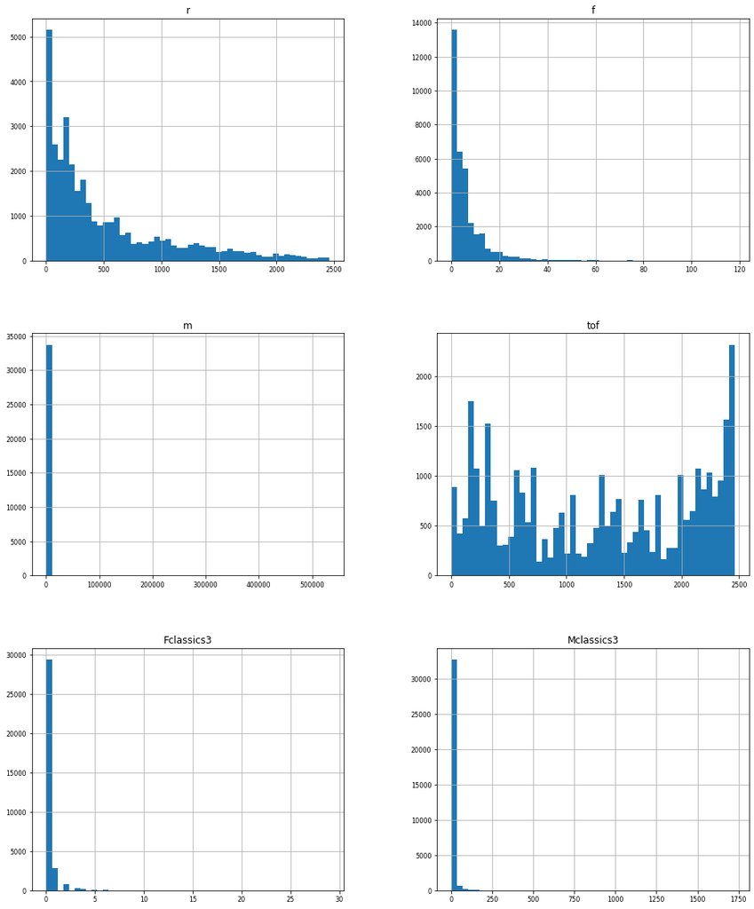

```python
# Plot histogram on selected variables
df[['r','f','m','tof','Fclassics3','Mclassics3']].hist(figsize=(16, 20), bins=50, xlabelsize=8, ylabelsize=8)
```

## 2. Create a new data set with more descriptive labels and the data needed for analysis

Rename data columns to make it more descriptive

```python
col = list(df.columns)
def relabel_data(col):
    for i in range(len(col)):
        if col[i] == 'r':
            col[i] = 'recency'
        elif col[i] == 'f':
            col[i] = 'overall frequency'
        elif  col[i] == 'm':
            col[i] = 'overall monetary'
        elif  col[i] == 'tof':
            col[i] = 'time on file in days'
        elif  col[i][0] == 'F':
            col[i] = 'frequency: ' + col[i] [1:]
            col[i] = re.sub(r'\d+', ' books', col[i]) if 'nonbooks' not in col[i] else re.sub(r'\d+', '', col[i])
        elif  col[i][0] == 'M':
            col[i] = 'monetary: ' + col[i] [1:]
            col[i] = re.sub(r'\d+', ' books', col[i]) if 'nonbooks' not in col[i] else re.sub(r'\d+', '', col[i])

    return col

df.columns = relabel_data(col)
```

```python
df.head()
```

|  | id | recency | overall frequency | overall monetary | time on file in days | frequency: fiction books | frequency: classics books | frequency: cartoons books | frequency: legends books | frequency: philosophy books | ... | monetary: health books | monetary: cooking books | monetary: learning books | monetary: GamesRiddles books | monetary: sports books | monetary: hobby books | monetary: nature books | monetary: encyclopaedia books | monetary: videos books | monetary: nonbooks |
| --- | --- | --- | --- | --- | --- | --- | --- | --- | --- | --- | --- | --- | --- | --- | --- | --- | --- | --- | --- | --- | --- |
| 0 | 914 | 194 | 7 | 318.894775 | 1703 | 1 | 0 | 1 | 0 | 0 | ... | 14.899994 | 10.174706 | 0.000000 | 0.0 | 0.0 | 0.000000 | 0.000000 | 0.0 | 0.000000 | 0.0 |
| 1 | 957 | 3 | 14 | 368.052246 | 2364 | 1 | 0 | 2 | 0 | 0 | ... | 74.156250 | 0.000000 | 22.749985 | 0.0 | 0.0 | 61.176025 | 17.150269 | 10.0 | 0.000000 | 0.0 |
| 2 | 1406 | 1489 | 15 | 423.298340 | 2371 | 0 | 0 | 0 | 0 | 0 | ... | 0.000000 | 0.000000 | 0.000000 | 0.0 | 0.0 | 0.000000 | 0.000000 | 0.0 | 0.000000 | 0.0 |
| 3 | 1414 | 155 | 4 | 71.217041 | 1290 | 0 | 0 | 0 | 0 | 0 | ... | 0.000000 | 0.000000 | 0.000000 | 0.0 | 0.0 | 0.000000 | 0.000000 | 0.0 | 0.000000 | 0.0 |
| 4 | 1546 | 194 | 6 | 442.638184 | 2188 | 0 | 0 | 1 | 0 | 3 | ... | 41.518219 | 0.000000 | 7.949997 | 0.0 | 0.0 | 17.895203 | 0.000000 | 0.0 | 61.799988 | 0.0 |

5 rows × 65 columns

Nearly all continuous variables are right skewed.

## 6. Choose either a “supervised” or an “unsupervised” approach to segment/cluster current customers using the data provided

Here I will implement RFM approach, which is an unsupervised learning.

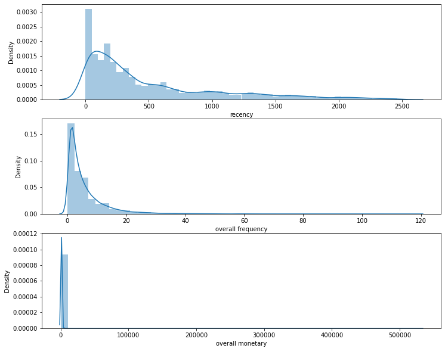

```python
# Plot RFM distributions
plt.figure(figsize=(12,10))
# Plot distribution of R
plt.subplot(3, 1, 1); sns.distplot(df['recency'])
# Plot distribution of F
plt.subplot(3, 1, 2); sns.distplot(df['overall frequency'])
# Plot distribution of M
plt.subplot(3, 1, 3); sns.distplot(df['overall monetary'])
# Show the plot
plt.show()
```

```python
# --Calculate R, F and M groups--
# Create labels for Recency and Frequency
r_labels = range(4, 0, -1); f_labels = range(1, 5); m_labels = range(1, 5)
# Assign these labels to 4 equal percentile groups
r_groups = pd.qcut(df['recency'], q=4, labels=r_labels)
# Assign these labels to 4 equal percentile groups
f_groups = pd.qcut(df['overall frequency'], q=4, labels=f_labels)
# Create new columns R and F
df_process = df.assign(R = r_groups.values, F = f_groups.values)
# Create labels for MonetaryValue
# Assign these labels to three equal percentile groups
m_groups = pd.qcut(df['overall monetary'], q=4, labels=m_labels)
# Create new column M
df_process = df_process.assign(M = m_groups.values)
```

```python
# Concat RFM quartile values to create RFM Segments
def join_rfm(x): return str(int(x['R'])) + str(int(x['F'])) + str(int(x['M']))
df_process['RFM_Segment_Concat'] = df_process.apply(join_rfm, axis=1)
rfm = df_process[['recency','overall frequency','overall monetary',
                 'time on file in days','R','F','M','RFM_Segment_Concat']]
rfm.head()
```

|  | recency | overall frequency | overall monetary | time on file in days | R | F | M | RFM_Segment_Concat |
| --- | --- | --- | --- | --- | --- | --- | --- | --- |
| 0 | 194 | 7 | 318.894775 | 1703 | 3 | 3 | 4 | 334 |
| 1 | 3 | 14 | 368.052246 | 2364 | 4 | 4 | 4 | 444 |
| 2 | 1489 | 15 | 423.298340 | 2371 | 1 | 4 | 4 | 144 |
| 3 | 155 | 4 | 71.217041 | 1290 | 3 | 3 | 2 | 332 |
| 4 | 194 | 6 | 442.638184 | 2188 | 3 | 3 | 4 | 334 |

```python
# Count num of unique segments
rfm_count_unique = rfm.groupby('RFM_Segment_Concat')['RFM_Segment_Concat'].nunique()
print(rfm_count_unique.sum())
```

```
61
```

RFM_Segment_Concat was created to have different segmentations created but there are a lot of unique segments so we need a different way to define segments.

```python
# Calculate RFM_Score
rfm['RFM_Score'] = rfm[['R','F','M']].sum(axis=1)
print(rfm['RFM_Score'].head())
```

```
0    10
1    12
2     9
3     8
4    10
Name: RFM_Score, dtype: int64
```

The logic here is to first sum RFM together, then depending on the result I assign different segment names. The higher the score, the more loyal the users are to the website.

```python
# Define rfm_level function
def rfm_level(df):
    if df['RFM_Score'] >= 9:
        return 'Can\'t Loose Them'
    elif ((df['RFM_Score'] >= 8) and (df['RFM_Score'] < 9)):
        return 'Champions'
    elif ((df['RFM_Score'] >= 7) and (df['RFM_Score'] < 8)):
        return 'Loyal'
    elif ((df['RFM_Score'] >= 6) and (df['RFM_Score'] < 7)):
        return 'Potential'
    elif ((df['RFM_Score'] >= 5) and (df['RFM_Score'] < 6)):
        return 'Promising'
    elif ((df['RFM_Score'] >= 4) and (df['RFM_Score'] < 5)):
        return 'Needs Attention'
    else:
        return 'Require Activation'
# Create a new variable RFM_Level
rfm['RFM_Level'] = rfm.apply(rfm_level, axis=1)
# Print the header with top 5 rows to the console
rfm.head()
```

|  | recency | overall frequency | overall monetary | time on file in days | R | F | M | RFM_Segment_Concat | RFM_Score | RFM_Level |
| --- | --- | --- | --- | --- | --- | --- | --- | --- | --- | --- |
| 0 | 194 | 7 | 318.894775 | 1703 | 3 | 3 | 4 | 334 | 10 | Can't Loose Them |
| 1 | 3 | 14 | 368.052246 | 2364 | 4 | 4 | 4 | 444 | 12 | Can't Loose Them |
| 2 | 1489 | 15 | 423.298340 | 2371 | 1 | 4 | 4 | 144 | 9 | Can't Loose Them |
| 3 | 155 | 4 | 71.217041 | 1290 | 3 | 3 | 2 | 332 | 8 | Champions |
| 4 | 194 | 6 | 442.638184 | 2188 | 3 | 3 | 4 | 334 | 10 | Can't Loose Them |

```python
# Calculate average values for each RFM_Level, and return a size of each segment
rfm_level_agg = rfm.groupby('RFM_Level').agg({
    'recency': 'mean',
    'overall frequency': 'mean',
    'overall monetary': ['mean', 'count']
}).round(1)
# Print the aggregated dataset
print(rfm_level_agg)
```

```
                   recency overall frequency overall monetary
                      mean              mean             mean  count
RFM_Level
Can't Loose Them     217.2              11.6            552.1  12359
Champions            431.0               4.5            164.9   3804
Loyal                577.6               3.5            112.4   3857
Needs Attention      862.4               1.2             30.5   3089
Potential            535.8               2.1             63.8   4483
Promising            694.9               1.6             44.2   4462
Require Activation  1460.3               1.0             19.0   1659
```

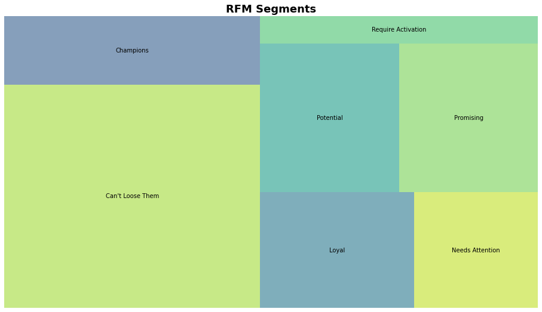

```python
rfm_level_agg.columns = ['recencymean','frequencymean','monetarymean', 'count']
#Create our plot and resize it.
fig = plt.gcf()
ax = fig.add_subplot()
fig.set_size_inches(16, 9)
squarify.plot(sizes=rfm_level_agg['count'],
              label=['Can\'t Loose Them',
                     'Champions',
                     'Loyal',
                     'Needs Attention',
                     'Potential',
                     'Promising',
                     'Require Activation'], alpha=.6 )
plt.title("RFM Segments",fontsize=18,fontweight="bold")
plt.axis('off')
plt.show()
```

Feed in dummy sample data to test which segment they belong to

```python
df_test = pd.DataFrame({'recency':[24,136,278,699,1988],'overall frequency':[1,2,4,6,18],'overall monetary':[788,244,200,1768,1345]})
```

```python
df_test
```

|  | recency | overall frequency | overall monetary |
| --- | --- | --- | --- |
| 0 | 24 | 1 | 788 |
| 1 | 136 | 2 | 244 |
| 2 | 278 | 4 | 200 |
| 3 | 699 | 6 | 1768 |
| 4 | 1988 | 18 | 1345 |

```python
# Define function for RFM approach
def RFM(df):
    # --Calculate R, F and M groups--
    # Create labels for Recency and Frequency
    r_labels = range(4, 0, -1); f_labels = range(1, 5); m_labels = range(1, 5)
    # Assign these labels to 4 equal percentile groups
    r_groups = pd.qcut(df['recency'], q=4, labels=r_labels)
    # Assign these labels to 4 equal percentile groups
    f_groups = pd.qcut(df['overall frequency'], q=4, labels=f_labels)
    # Create new columns R and F
    df_process = df.assign(R = r_groups.values, F = f_groups.values)
    # Create labels for MonetaryValue
    # Assign these labels to three equal percentile groups
    m_groups = pd.qcut(df['overall monetary'], q=4, labels=m_labels)
    # Create new column M
    df_process = df_process.assign(M = m_groups.values)
    rfm = df_process
    # Calculate RFM_Score
    rfm['RFM_Score'] = rfm[['R','F','M']].sum(axis=1)
    # Define rfm_level function
    # Create a new variable RFM_Level
    rfm['RFM_Level'] = rfm.apply(rfm_level, axis=1)
    return rfm['RFM_Level']
```

Predicted results for the five test users

```python
RFM(df_test)
```

```
0               Loyal
1           Potential
2           Potential
3    Can't Loose Them
4           Champions
Name: RFM_Level, dtype: object
```